# Atividade 03

### 1 Vetores aleatórios com sample()

##### 1.1 Amostragem com e sem reposição

Descreva como obter o listado a seguir com o uso da função sample().

- 1. Uma turma tem 45 alunos. Vai se escolher uma comissão de cinco representantes selecionando os indivíduos ao acaso.

```r
sample(45,5)
```

```
[1]  8 42  9  1  4
```

- 2. Obter uma sequencia de resultados de 10 lançamentos de uma moeda.

```r
moeda <- c("k","c")
sample(moeda,10, replace = T)
```

```
 [1] "k" "k" "c" "c" "c" "c" "c" "k" "k" "c"
```

- 3. Utilizando os algarismos 0 a 9 obter um número de 4 algarismos.

```r
paste(sample(0:9, 4, replace = TRUE), collapse = "")
```

```
[1] "6867"
```

- 4. Em uma corrida de automóveis com 20 pilotos obter um possível pódium (três primeiros colocados), considerando chances iguais de resultados entre os pilotos.

```r
sample(1:20, 3, replace = FALSE)
```

```
[1]  4 10  2
```

##### 1.2 Opções da função

- 1. Acesse informações sobre função sample() (use args(sample) e help(sample)). Descreva o uso e crie exemplos do uso de cada um dos argumentos da função.

```r
help(sample)
```

##### 1.3 Lançamentos de um dado

- 1. Use a função sample() para simular o lançamento de um dado.

```r
dado <- 1:6
sample(dado,1)
```

```
[1] 4
```

- 2. Idem anterior porém agora 20 lançamentos.

```r
lanc_20 <- sample(dado, 20, replace = TRUE); lanc_20
```

```
 [1] 6 6 2 3 1 3 6 4 1 1 6 1 6 3 6 2 1 2 6 3
```

- 3. Verifique quantas foram as ocorrências de cada face.

```r
freq <- table(lanc_20); freq
```

```
lanc_20
1 2 3 4 6
5 3 4 1 7
```

- 4. Faça um gráfico do número obtido e o esperado de ocorrências das faces.

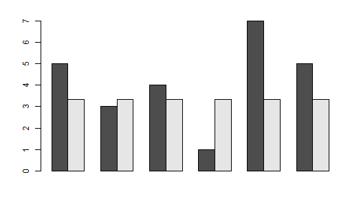

```r
esperado <- rep(20/6,6)

resultados <- rbind(as.numeric(freq),esperado)
barplot(resultados, beside = TRUE)
```

```r
NA
NA
```

- 5. Obtenha as frequências e proporções de cada face em 12, 60, 120, 600, 12.000 e 600.000 lançamentos. Avalie a proximidade dos resultados à frequencia esperada. Faça teste de aderência em cada caso. Voce notou algum resultado “potencialmente” contra intuitivo?

```r
lanc_dado <- function(qtd_lanc) {

  resultados <- sample(1:6,qtd_lanc,replace = T)

  freq <-  table(factor(resultados, levels = 1:6))

  prop <-  freq/qtd_lanc

  prop_esp <- sum((prop - rep(1/6,6))**2)

  desvio_perc <- sqrt(prop_esp) * 100


  cat("Quantidade de lançamentos:", qtd_lanc, "\n\n")

  cat("Frequências observadas:\n")
  print(freq)

  cat("\nProporções observadas:\n")
  print(round(prop, 4))

  cat("Desvio quadrático das proporções em relação ao esperado:", round(prop_esp, 6), desvio_perc, "\n")


  cat("Resultado do teste qui-quadrado:\n")
  print(chisq.test(freq, p = rep(1/6, 6)))

}
lanc_dado(12)
```

```
Quantidade de lançamentos: 12

Frequências observadas:

1 2 3 4 5 6
2 3 4 1 0 2

Proporções observadas:

     1      2      3      4      5      6
0.1667 0.2500 0.3333 0.0833 0.0000 0.1667
Desvio quadrático das proporções em relação ao esperado: 0.069444 26.35231
Resultado do teste qui-quadrado:
```

```
    Chi-squared test for given probabilities

data:  freq
X-squared = 5, df = 5, p-value = 0.4159
```

```r
lanc_dado(60)
```

```
Quantidade de lançamentos: 60

Frequências observadas:

 1  2  3  4  5  6
 8 15  9 12  8  8

Proporções observadas:

     1      2      3      4      5      6
0.1333 0.2500 0.1500 0.2000 0.1333 0.1333
Desvio quadrático das proporções em relação ao esperado: 0.011667 10.80123
Resultado do teste qui-quadrado:

    Chi-squared test for given probabilities

data:  freq
X-squared = 4.2, df = 5, p-value = 0.521
```

```r
lanc_dado(120)
```

```
Quantidade de lançamentos: 120

Frequências observadas:

 1  2  3  4  5  6
15 26 24 19 15 21

Proporções observadas:

     1      2      3      4      5      6
0.1250 0.2167 0.2000 0.1583 0.1250 0.1750
Desvio quadrático das proporções em relação ao esperado: 0.007222 8.498366
Resultado do teste qui-quadrado:

    Chi-squared test for given probabilities

data:  freq
X-squared = 5.2, df = 5, p-value = 0.392
```

```r
lanc_dado(600)
```

```
Quantidade de lançamentos: 600

Frequências observadas:

  1   2   3   4   5   6
 98 101 102 100 103  96

Proporções observadas:

     1      2      3      4      5      6
0.1633 0.1683 0.1700 0.1667 0.1717 0.1600
Desvio quadrático das proporções em relação ao esperado: 9.4e-05 0.9718253
Resultado do teste qui-quadrado:

    Chi-squared test for given probabilities

data:  freq
X-squared = 0.34, df = 5, p-value = 0.9968
```

```r
lanc_dado(12000)
```

```
Quantidade de lançamentos: 12000

Frequências observadas:

   1    2    3    4    5    6
1963 1994 1982 2033 2027 2001

Proporções observadas:

     1      2      3      4      5      6
0.1636 0.1662 0.1652 0.1694 0.1689 0.1668
Desvio quadrático das proporções em relação ao esperado: 2.5e-05 0.4963758
Resultado do teste qui-quadrado:

    Chi-squared test for given probabilities

data:  freq
X-squared = 1.774, df = 5, p-value = 0.8794
```

```r
lanc_dado(600000)
```

```
Quantidade de lançamentos: 6e+05

Frequências observadas:

     1      2      3      4      5      6
 99980  99959 100499  99689  99824 100049

Proporções observadas:

     1      2      3      4      5      6
0.1666 0.1666 0.1675 0.1661 0.1664 0.1667
Desvio quadrático das proporções em relação ao esperado: 1e-06 0.1028996
Resultado do teste qui-quadrado:

    Chi-squared test for given probabilities

data:  freq
X-squared = 3.8118, df = 5, p-value = 0.5768
```

- 6. Simule agora o lançamento de dois dados e obtenha a soma das faces.

```r
dado_1 <- sample(1:6,1800,replace = T)
dado_2 <- sample(1:6,1800,replace = T)

sum_dado <-  dado_1 +dado_2
```

- 7. Obtenha a frequência dos valores da soma das faces em 1800 lançamentos de dois dados. Compare com o valor teórico e faça um gráfico adequado.

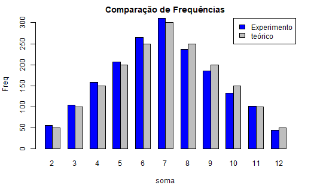

```r
dado_1 <- sample(1:6,1800,replace = T)
dado_2 <- sample(1:6,1800,replace = T)

sum_dado <-  table(dado_1 +dado_2)



soma_dados <- table(outer(1:6, 1:6, FUN = "+"))/36*1800

# Combinar as tabelas
tabelas <- rbind(as.numeric(sum_dado), as.numeric(soma_dados))

# Desenhar o gráfico
barplot(tabelas,
        beside = TRUE,
        col = c("blue", "grey"),
        names.arg = names(sum_dado),
        main = "Comparação de Frequências",
        xlab = "soma",
        ylab = "Freq")

legend("topright", legend = c("Experimento", "teórico"), fill = c("blue", "grey"))
```

##### 1.4 Amostrando conjunto de dados

Considere o conjunto de dados mtcars incluído no R.

```r
mtcars
```

|  | mpg | cyl | disp | hp | drat | wt | qsec | vs | am | gear | carb |
| --- | --- | --- | --- | --- | --- | --- | --- | --- | --- | --- | --- |
| Mazda RX4 | 21.0 | 6 | 160.0 | 110 | 3.90 | 2.620 | 16.46 | 0 | 1 | 4 | 4 |
| Mazda RX4 Wag | 21.0 | 6 | 160.0 | 110 | 3.90 | 2.875 | 17.02 | 0 | 1 | 4 | 4 |
| Datsun 710 | 22.8 | 4 | 108.0 | 93 | 3.85 | 2.320 | 18.61 | 1 | 1 | 4 | 1 |
| Hornet 4 Drive | 21.4 | 6 | 258.0 | 110 | 3.08 | 3.215 | 19.44 | 1 | 0 | 3 | 1 |
| Hornet Sportabout | 18.7 | 8 | 360.0 | 175 | 3.15 | 3.440 | 17.02 | 0 | 0 | 3 | 2 |
| Valiant | 18.1 | 6 | 225.0 | 105 | 2.76 | 3.460 | 20.22 | 1 | 0 | 3 | 1 |
| Duster 360 | 14.3 | 8 | 360.0 | 245 | 3.21 | 3.570 | 15.84 | 0 | 0 | 3 | 4 |
| Merc 240D | 24.4 | 4 | 146.7 | 62 | 3.69 | 3.190 | 20.00 | 1 | 0 | 4 | 2 |
| Merc 230 | 22.8 | 4 | 140.8 | 95 | 3.92 | 3.150 | 22.90 | 1 | 0 | 4 | 2 |
| Merc 280 | 19.2 | 6 | 167.6 | 123 | 3.92 | 3.440 | 18.30 | 1 | 0 | 4 | 4 |

[output cut: 22 more lines]

- 1. Componha um novo objeto selecionando, ao acaso, cinco linhas deste conjunto de dados.

```r
linhas <- sample(1:nrow(mtcars),5)

amostra <- mtcars[linhas,]
```

- 2. Compare o consumo (mpg) médio calculado com os dados originais e no subconjunto obtido.

```r
mean(amostra$mpg)
```

```
[1] 17.98
```

```r
mean(mtcars$mpg)
```

```
[1] 20.09062
```

- 3. Repita a criação do novo conjunto e cálculo da média de mpg 1000 vezes. Compare agora os 1000 valores de médias obtidas com a média original calculada com todos os dados. Discuta os resultados.

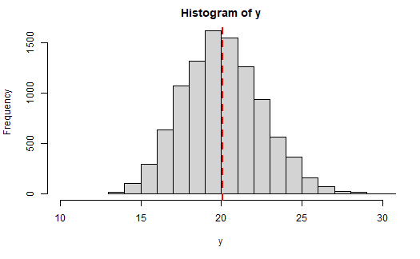

```r
ams <- function(n){

  med_ams <- numeric(n)


  for (i in 1:n){
    linhas <- sample(1:nrow(mtcars),5)

    amostra <- mtcars[linhas,]

    med_ams[i] <- mean(amostra$mpg)

  }

  return(med_ams)
}

y <- ams(10000)

hist(y, xlim=c(10,30))
abline(v =mean(mtcars$mpg) , col = "red", lwd = 2, lty = 2)
```

##### 1.5 (Re)Amostrando com repetição

Repita o exercício anterior porém no passo (a.) retire amostras com reposição com tamanho igual ao tamanho dos dados. Discuta resultados e ainda semelhanças e diferenças com o problema anterior.

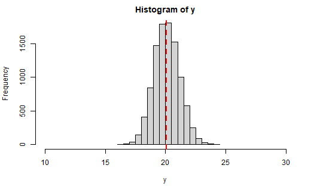

```r
ams <- function(n){

  med_ams <- numeric(n)


  for (i in 1:n){
    linhas <- sample(1:nrow(mtcars),nrow(mtcars), replace = T)

    amostra <- mtcars[linhas,]

    med_ams[i] <- mean(amostra$mpg)

  }

  return(med_ams)
}


y <- ams(10000)

hist(y, xlim=c(10,30))
abline(v =mean(mtcars$mpg) , col = "red", lwd = 2, lty = 2)
```

```r
NA
NA
NA
```

### 2 Vetores aleatórios com runif()

##### 2.1 Simulando e visualizando simulações

- 1. Acesse informações sobre função runif() (use args(runif) e help(runif)).

```r
args(runif)
```

```
function (n, min = 0, max = 1)
NULL
```

- 2. Use a função para gerar 10 valores. Armazene os valores em um objeto chamado y1.

```r
y1 <- runif(10)
y1
```

```
 [1] 0.35289468 0.98766097 0.85655445 0.01926274 0.90462997 0.94828185 0.95834744 0.64655203 0.69145363 0.88714916
```

- 3. Rode a função novamente gerando 10 valores. Armazene os valores em um objeto chamado y2. Os valores de y1 e y2 são iguais? Explique.

```r
y2 <- runif(10)

y1;y2
```

```
 [1] 0.35289468 0.98766097 0.85655445 0.01926274 0.90462997 0.94828185 0.95834744 0.64655203 0.69145363 0.88714916
 [1] 0.25639830 0.84463281 0.40471512 0.65753354 0.53989984 0.34018944 0.03881569 0.02150077 0.60628741 0.92541124
```

- 4. Gere agora um vetor com 10000 valores gerados por runif() e imagine fazer um histograma com estes valores. Qual o padrão que voce espera encontrar neste histograma? Use hist() para fazer o histograma e verifique se o padrão é o que voce imaginou. Use também density() para visualizar a distribuição empírica do dado.

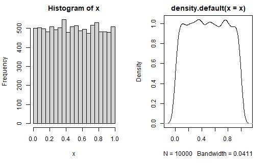

```r
x <- runif(10000)
par(mfrow = c(1, 2))

hist(x)
plot(density(x))
```

- 5. Coloque em mesmo um gráfico as distribuições acumuladas teórica e empírica (voce pode usar punif() e ecdf()).

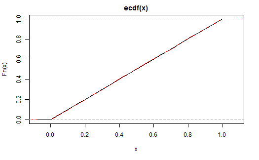

```r
ecdf_valores <- ecdf(x)

plot(ecdf_valores, col = 'red')
curve(punif(x), add = T)
```

##### 2.2 Simulando em outros intervalos

Utilizando runif():

- 1. Gere agora 8 valores aleatórios entre 4 e 10 de duas formas: usando argumentos de runif(), fazendo uma operação com valores gerados por runif(8).

```r
x <- runif(8,4,10)

y <- runif(8)*6 + 4

y
```

```
[1] 7.532949 4.845869 4.887490 4.015825 4.183937 9.638375 6.153503 7.884773
```

- 2. Simular o lançamento de 10 moedas.

```r
ifelse(runif(10)<0.5,"k","c")
```

```
 [1] "k" "k" "c" "k" "k" "k" "k" "k" "c" "k"
```

- 3. Simular 10 lançamento de um dado.

```r
floor(runif(10,1,7))
```

```
 [1] 5 4 1 6 1 3 6 4 4 4
```

- 4. Gere uma sequência (aleatória) de 20 resultados do lançamento de uma moeda.

```r
X <- ifelse(runif(20)<0.5,"k","c"); X
```

```
 [1] "c" "k" "k" "k" "c" "c" "c" "c" "c" "k" "c" "k" "k" "k" "k" "k" "k" "c" "c" "k"
```

- 5. Quantas caras e coroas voce espera? Quantas foram geradas?

```r
mean(X == "k")
```

```
[1] 0.55
```

- 6. Uma sequência (aleatória) de 30 resultados do lançamento de um dado.

```r
Y <-  floor(runif(30,1,7)) ; Y
```

```
 [1] 4 6 6 4 6 1 2 5 5 4 3 1 1 4 6 2 2 6 5 2 4 3 6 2 3 1 2 1 3 3
```

- 7. Quantas de cada face do dado voce espera observar? Quantas foram geradas?

```r
table(Y)
```

```
Y
1 2 3 4 5 6
5 6 5 5 3 6
```

### 3 Simulando com rnorm()

##### 3.1 Explorando simulações

- 1. Acesse informações sobre função rnorm() (use args(rnorm) e help(rnorm))

```r
args(rnorm)
```

```
function (n, mean = 0, sd = 1)
NULL
```

- 2. Gere 100 valores de uma distribuição normal padrão (ou seja, com média zero e desvio padrão 1) e faça um histograma destes valores.

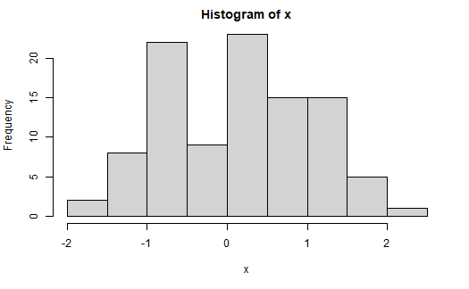

```r
x <- rnorm(100)

hist(x)
```

- 3. Simule 200 valores de uma distribuição normal de média 70 e desvio padrão 8. Compare os valores simulados com teóricos usando:

```r
Y <- rnorm(200,70,8)

teo <- dnorm(Y, 70,8)

#histograma (hist()),
par(mfrow = c(1, 2))
hist(Y)
curve(dnorm(x, mean = 70, sd = 8), from = 40, to = 100)
```

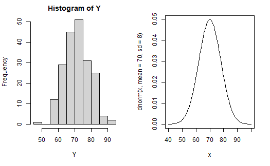

```r
#gráfico de densidade (density()),
par(mfrow = c(1, 2))
```

```r
plot(density(Y))
curve(dnorm(x, mean = 70, sd = 8), from = 40, to = 100)
```

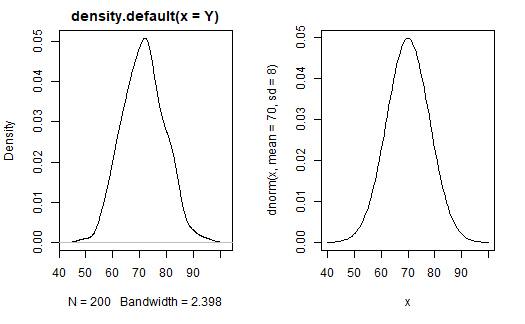

```r
#gráfico de distribuição acumulada (teórica e empírica),

par(mfrow = c(1, 2))
```

```r
plot(ecdf(Y))
curve(pnorm(x, mean = 70, sd = 8), col = "red", lwd = 2, add = TRUE)
```

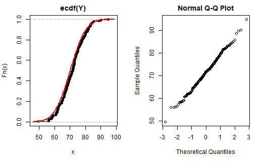

```r
#qq-plot normal (qqnorm()).


qqnorm(Y)
```

```r
NA
NA
```